# HomeWork 1

Ceren Özkan - IE582 - Fall 2020

HOMEWORK 1

Note: All codes and results are given at the end of the document.

TASK 1: In the first part of this task, we were asked to plot the histograms for the home and away goals. Hence, to get all the data, I constructed vectors for home and away goals. This vectors are consisted of 2018-2019, 2019-2020 and 2020-2021 data. By binding them, we can access all the information for all the years. The histograms can be found below.

Second part of the task ask us to find if the distribution can is likely to be Poisson. Hence, first I found the mean value of each vector to use as lambda. Then, using dpois function, I constructed some data that is distributed as Poisson. Then I fit that data into a line. By visually representing both the histograms and the lines, it can be seen that they are very likely. Hence we can say that our data’s distribution is consistent with Poisson distribution claim.

TASK 2: For this task, bookmarkers labeled as B365, BW, IW an PS is chosen. Data is bonded as in Task 1 to get all the results for years.

1. All the probabilities are calculated using P = 1/odds. Results can be found below.
2. All the probabilities are calculated again by using the normalization functions. 3-4) Corresponding plots are constructed with “P(Home)-P(Away)” as the x-axis and “P(Tie)” as the y-axis. I tried to bin the real results and visually represent them in the solutions but unfortunately I could not perform it. However, by reading the paper suggested in the homework, I undertood that an odds bias occurs since the odds probability varies from the real probabilities, hence the trend line changes and our data become biased.

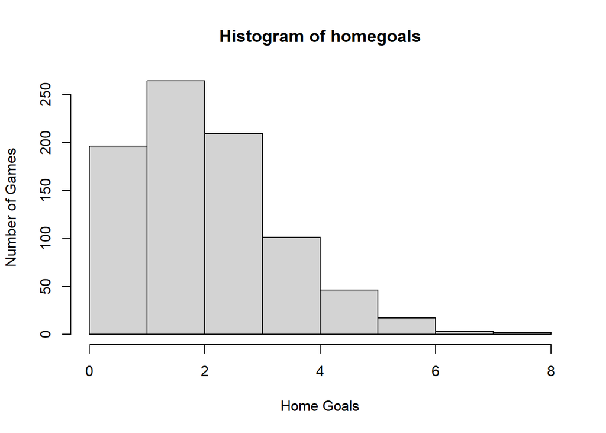

```r
library(ggplot2)
EPL2021 <- read.csv("C:/Users/HP/Downloads/E0 (1).csv", header=TRUE) #2020-2021 data
EPL1920 <- read.csv("C:/Users/HP/Downloads/E0.csv", header=TRUE)  #2019-2020 data
EPL1819 <- read.csv("C:/Users/HP/Downloads/E0 (2).csv", header=TRUE) #2018-2019 data

#1a
homegoals = c(EPL2021$FTHG,EPL1920$FTHG,EPL1819$FTHG);
hist(homegoals, xlab = 'Home Goals', ylab = 'Number of Games', right = F) ;
```

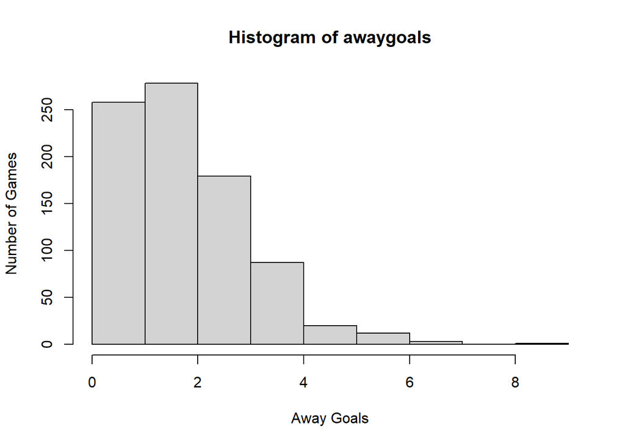

```r
awaygoals = c(EPL2021$FTAG,EPL1920$FTAG,EPL1819$FTAG)
hist(awaygoals, xlab = 'Away Goals', ylab = 'Number of Games', right = F)
```

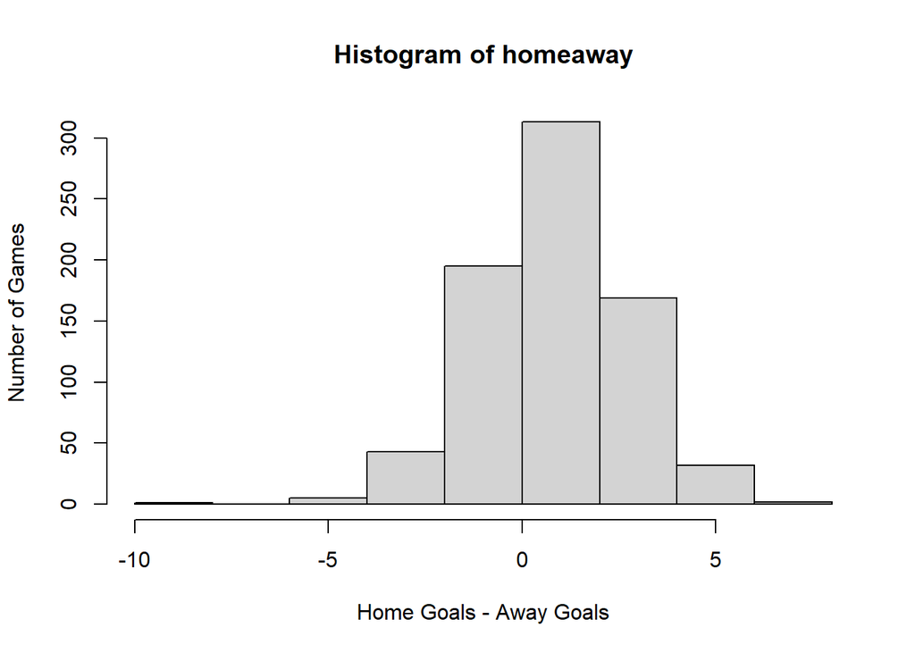

```r
homeaway = c(V1=( EPL2021$F4THG-EPL2021$FTAG), V2= (EPL1920$FTHG-EPL1920$FTAG), V3= (EPL1819$FTHG-EPL1819$FTAG))
hist(homeaway, xlab = 'Home Goals - Away Goals', ylab = 'Number of Games', right = F)
```

```r
#1b
x1 = dpois(c(0:5), mean(homegoals))
expectedNoOfMatchesHome= data.frame(0:5, round(838*x1))
table(homegoals)
```

```
## homegoals
##   0   1   2   3   4   5   6   7   8
## 196 264 209 101  46  17   3   1   1
```

```r
expectedNoOfMatchesHome
```

```
##   X0.5 round.838...x1.
## 1    0             180
## 2    1             277
## 3    2             213
## 4    3             109
## 5    4              42
## 6    5              13
```

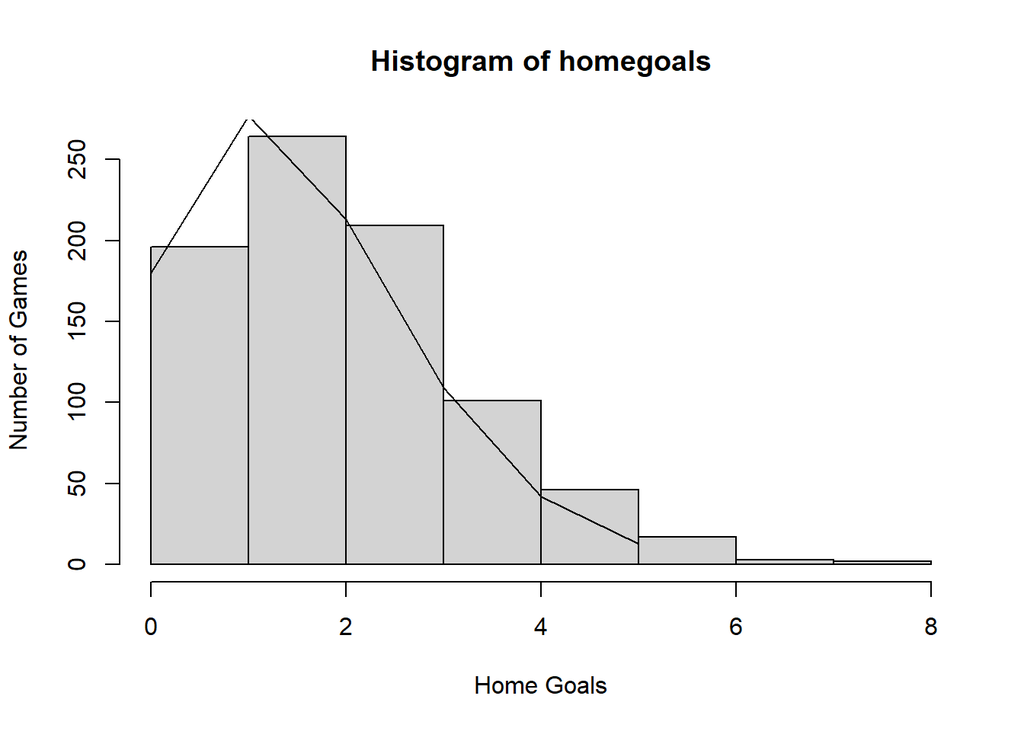

```r
hist(homegoals, xlab = 'Home Goals', ylab = 'Number of Games', right = F)
lines(expectedNoOfMatchesHome)
```

```r
x2 = dpois(c(0:5), mean(awaygoals))
expectedNoOfMatchesAway = data.frame(0:5, round(838*x2))
table(awaygoals)
```

```
## awaygoals
##   0   1   2   3   4   5   6   9
## 258 278 179  87  20  12   3   1
```

```r
expectedNoOfMatchesAway
```

```
##   X0.5 round.838...x2.
## 1    0             235
## 2    1             299
## 3    2             190
## 4    3              80
## 5    4              25
## 6    5               6
```

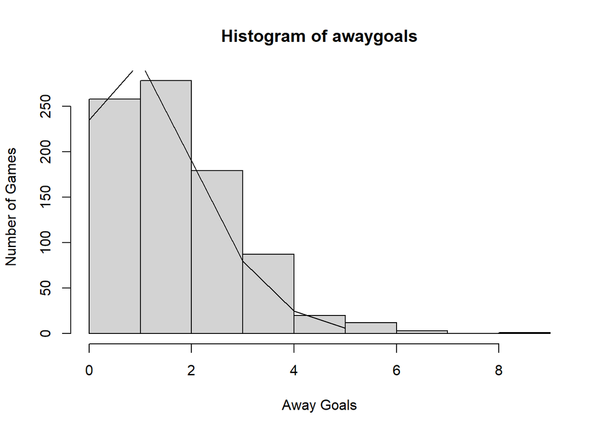

```r
hist(awaygoals, xlab = 'Away Goals', ylab = 'Number of Games', right = F)
lines(expectedNoOfMatchesAway)
```

```r
#2a
avgHomeOdds = c(EPL2021$B365H, EPL1920$B365H, EPL1819$B365H, EPL2021$BWH, EPL1920$BWH, EPL1819$BWH, EPL2021$IWH, EPL1920$IWH, EPL1819$IWH,EPL2021$PSH, EPL1920$PSH, EPL1819$PSH)
pAvgHome = 1/avgHomeOdds
mean(pAvgHome)
```

```
## [1] 0.4600872
```

```r
avgTieOdds = c(EPL2021$B365D, EPL1920$B365D, EPL1819$B365D, EPL2021$BWD, EPL1920$BWD, EPL1819$BWD, EPL2021$IWD, EPL1920$IWD, EPL1819$IWD,EPL2021$PSD, EPL1920$PSD, EPL1819$PSD)
pAvgTie = 1/avgTieOdds
mean(pAvgTie)
```

```
## [1] 0.2501311
```

```r
avgAwayOdds = c(EPL2021$B365A, EPL1920$B365A, EPL1819$B365A, EPL2021$BWA, EPL1920$BWA, EPL1819$BWA, EPL2021$IWA, EPL1920$IWA, EPL1819$IWA,EPL2021$PSA, EPL1920$PSA, EPL1819$PSA)
pAvgAway = 1/avgAwayOdds
mean(pAvgAway)
```

```
## [1] 0.3328127
```

```r
#2b
totalInverseOdds = pAvgHome+pAvgTie+pAvgAway
totalOdds = 1/totalInverseOdds

pHomeNormal = pAvgHome*totalOdds
mean(pHomeNormal)
```

```
## [1] 0.4410851
```

```r
pTieNormal = pAvgTie*totalOdds
mean(pTieNormal)
```

```
## [1] 0.2398378
```

```r
pAwayNormal = pAvgAway*totalOdds
mean(pAwayNormal)
```

```
## [1] 0.3190771
```

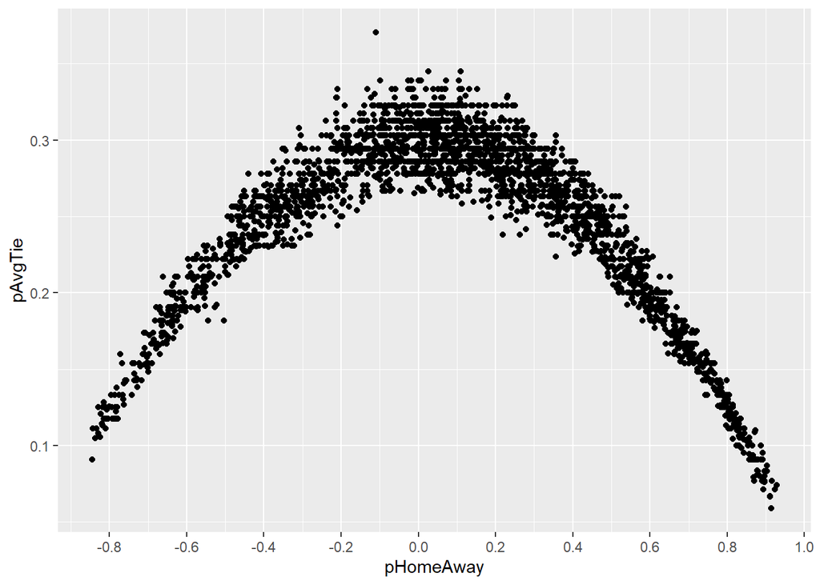

```r
#2c
pHomeAway = pAvgHome - pAvgAway

data = cbind(pHomeAway,pAvgTie)
df=data.frame(data)
ggplot(df, aes(x=pHomeAway, y=pAvgTie)) + geom_point() + scale_x_continuous(breaks = c(-1,-0.8,-0.6,-0.4,-0.2,0,0.2,0.4,0.6,0.8,1))
```

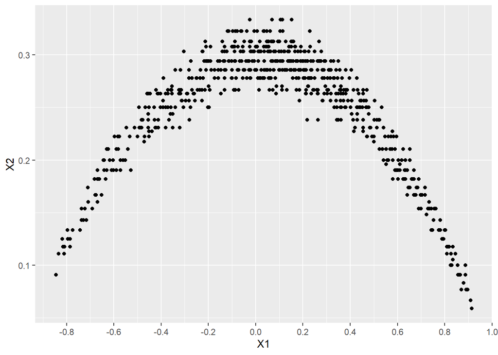

```r
#2d
homeOddsB365 =c(EPL2021$B365H, EPL1920$B365H, EPL1819$B365H)
awayOddsB365 =c(EPL2021$B365A, EPL1920$B365A, EPL1819$B365A)
drawOddsB365 =c(EPL2021$B365D, EPL1920$B365D, EPL1819$B365D)
dfB365 = data.frame(cbind((1/homeOddsB365)-(1/awayOddsB365), 1/drawOddsB365))
ggplot(dfB365, aes(x=X1, y=X2)) + geom_point() + scale_x_continuous(breaks = c(-1,-0.8,-0.6,-0.4,-0.2,0,0.2,0.4,0.6,0.8,1))
```

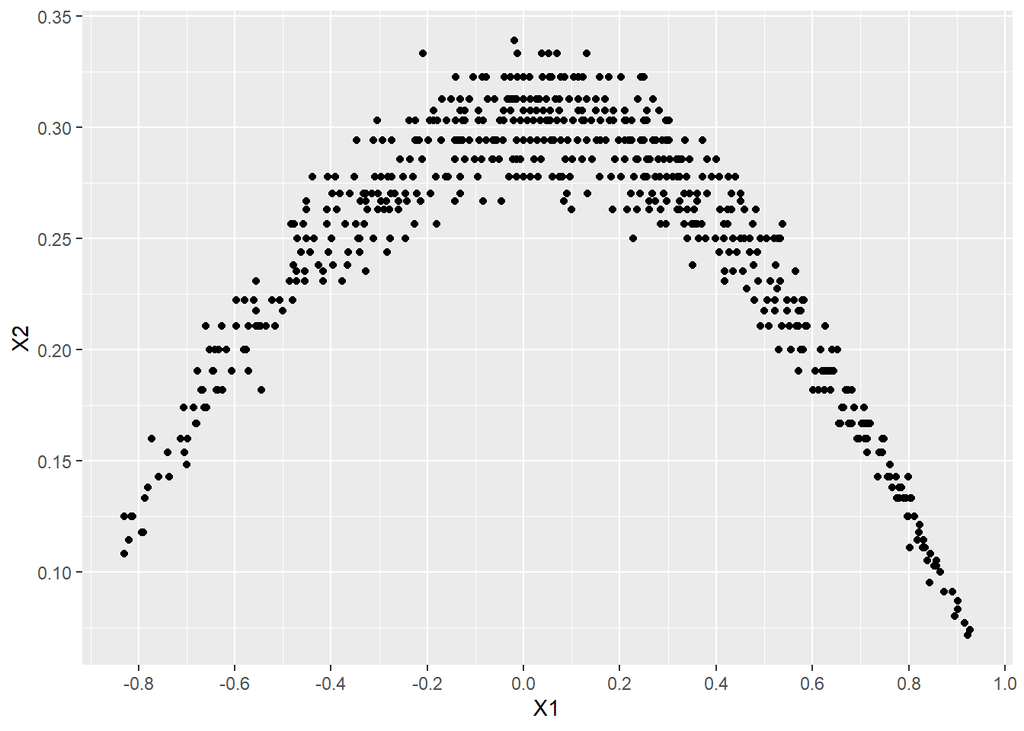

```r
homeOddsBW =c(EPL2021$BWH, EPL1920$BWH, EPL1819$BWH)
awayOddsBW =c(EPL2021$BWA, EPL1920$BWA, EPL1819$BWA)
drawOddsBW =c(EPL2021$BWD, EPL1920$BWD, EPL1819$BWD)
dfBW = data.frame(cbind((1/homeOddsBW)-(1/awayOddsBW), 1/drawOddsBW))
ggplot(dfBW, aes(x=X1, y=X2)) + geom_point() + scale_x_continuous(breaks = c(-1,-0.8,-0.6,-0.4,-0.2,0,0.2,0.4,0.6,0.8,1))
```

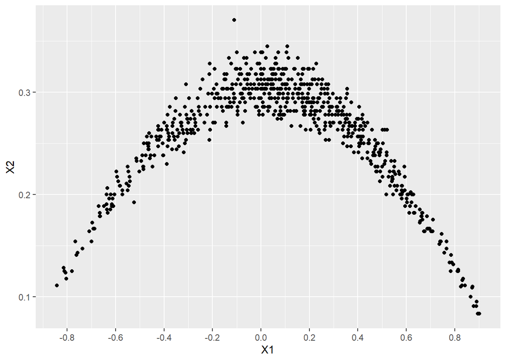

```r
homeOddsIW =c(EPL2021$IWH, EPL1920$IWH, EPL1819$IWH)
awayOddsIW =c(EPL2021$IWA, EPL1920$IWA, EPL1819$IWA)
drawOddsIW =c(EPL2021$IWD, EPL1920$IWD, EPL1819$IWD)
dfIW = data.frame(cbind((1/homeOddsIW)-(1/awayOddsIW), 1/drawOddsIW))
ggplot(dfIW, aes(x=X1, y=X2)) + geom_point() + scale_x_continuous(breaks = c(-1,-0.8,-0.6,-0.4,-0.2,0,0.2,0.4,0.6,0.8,1))
```

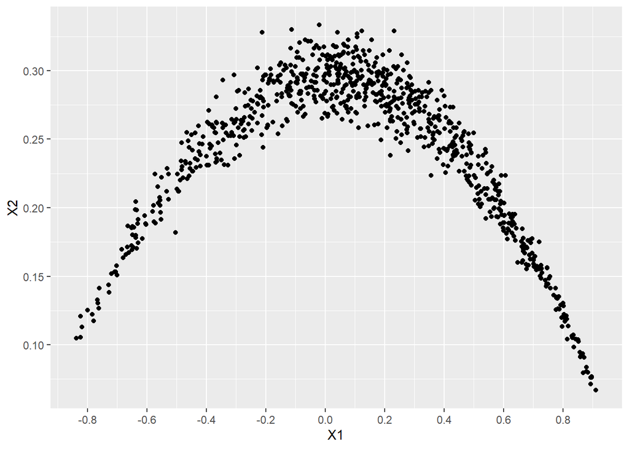

```r
homeOddsPS =c(EPL2021$PSH, EPL1920$PSH, EPL1819$PSH)
awayOddsPS =c(EPL2021$PSA, EPL1920$PSA, EPL1819$PSA)
drawOddsPS =c(EPL2021$PSD, EPL1920$PSD, EPL1819$PSD)
dfPS = data.frame(cbind((1/homeOddsPS)-(1/awayOddsPS), 1/drawOddsPS))
ggplot(dfPS, aes(x=X1, y=X2)) + geom_point() + scale_x_continuous(breaks = c(-1,-0.8,-0.6,-0.4,-0.2,0,0.2,0.4,0.6,0.8,1))
```

```r
#TASK 3

EPL1819NoNoise =EPL1819[!(EPL1819$HR== 1 | EPL1819$HR==2 | EPL1819$AR==1 | EPL1819$AR==2),]
EPL1920NoNoise =EPL1920[!(EPL1920$HR== 1 | EPL1920$HR==2 | EPL1920$AR==1 | EPL1920$AR==2),]
EPL2021NoNoise = EPL1920[!(EPL1920$HR== 1 | EPL1920$HR==2 | EPL1920$AR==1 | EPL1920$AR==2),]


avgHomeOddsNoNoise = c(EPL2021NoNoise$B365H, EPL1920NoNoise$B365H, EPL1819NoNoise$B365H, EPL2021NoNoise$BWH, EPL1920NoNoise$BWH, EPL1819NoNoise$BWH, EPL2021NoNoise$IWH, EPL1920NoNoise$IWH, EPL1819NoNoise$IWH,EPL2021NoNoise$PSH, EPL1920NoNoise$PSH, EPL1819NoNoise$PSH)
pAvgHomeNoNoise = 1/avgHomeOddsNoNoise
mean(pAvgHomeNoNoise)
```

```
## [1] 0.4659524
```

```r
avgTieOddsNoNoise = c(EPL2021NoNoise$B365D, EPL1920NoNoise$B365D, EPL1819NoNoise$B365D, EPL2021NoNoise$BWD, EPL1920NoNoise$BWD, EPL1819NoNoise$BWD, EPL2021NoNoise$IWD, EPL1920NoNoise$IWD, EPL1819NoNoise$IWD,EPL2021NoNoise$PSD, EPL1920NoNoise$PSD, EPL1819NoNoise$PSD)
pAvgTieNoNoise = 1/avgTieOddsNoNoise
mean(pAvgTieNoNoise)
```

```
## [1] 0.2468111
```

```r
avgAwayOddsNoNoise = c(EPL2021NoNoise$B365A, EPL1920NoNoise$B365A, EPL1819NoNoise$B365A, EPL2021NoNoise$BWA, EPL1920NoNoise$BWA, EPL1819NoNoise$BWA, EPL2021NoNoise$IWA, EPL1920NoNoise$IWA, EPL1819NoNoise$IWA,EPL2021NoNoise$PSA, EPL1920NoNoise$PSA, EPL1819NoNoise$PSA)
pAvgAwayNoNoise = 1/avgAwayOddsNoNoise
mean(pAvgAwayNoNoise)
```

```
## [1] 0.3311233
```

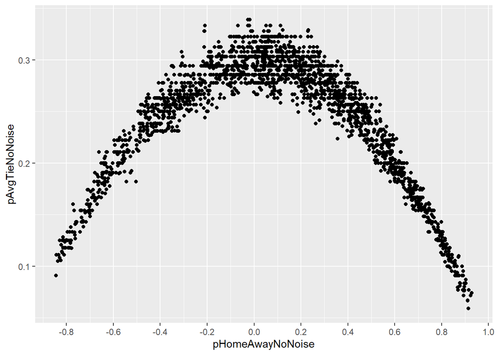

```r
pHomeAwayNoNoise = pAvgHomeNoNoise - pAvgAwayNoNoise
dataNoNoise = cbind(pHomeAwayNoNoise,pAvgTieNoNoise)
dfNoNoise=data.frame(dataNoNoise)
ggplot(dfNoNoise, aes(x=pHomeAwayNoNoise, y=pAvgTieNoNoise)) + geom_point() + scale_x_continuous(breaks = c(-1,-0.8,-0.6,-0.4,-0.2,0,0.2,0.4,0.6,0.8,1))
```

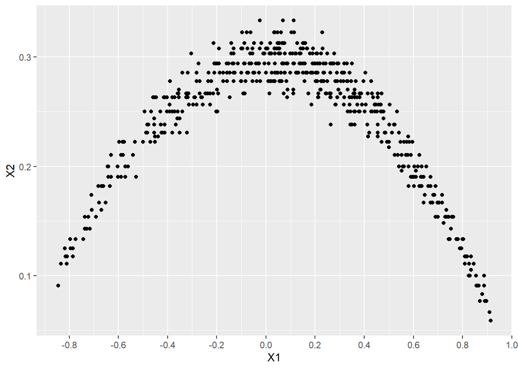

```r
homeOddsB365NoNoise =c(EPL2021NoNoise$B365H, EPL1920NoNoise$B365H, EPL1819NoNoise$B365H)
awayOddsB365NoNoise =c(EPL2021NoNoise$B365A, EPL1920NoNoise$B365A, EPL1819NoNoise$B365A)
drawOddsB365NoNoise =c(EPL2021NoNoise$B365D, EPL1920NoNoise$B365D, EPL1819NoNoise$B365D)
dfB365NoNoise = data.frame(cbind((1/homeOddsB365NoNoise)-(1/awayOddsB365NoNoise), 1/drawOddsB365NoNoise))
ggplot(dfB365NoNoise, aes(x=X1, y=X2)) + geom_point() + scale_x_continuous(breaks = c(-1,-0.8,-0.6,-0.4,-0.2,0,0.2,0.4,0.6,0.8,1))
```

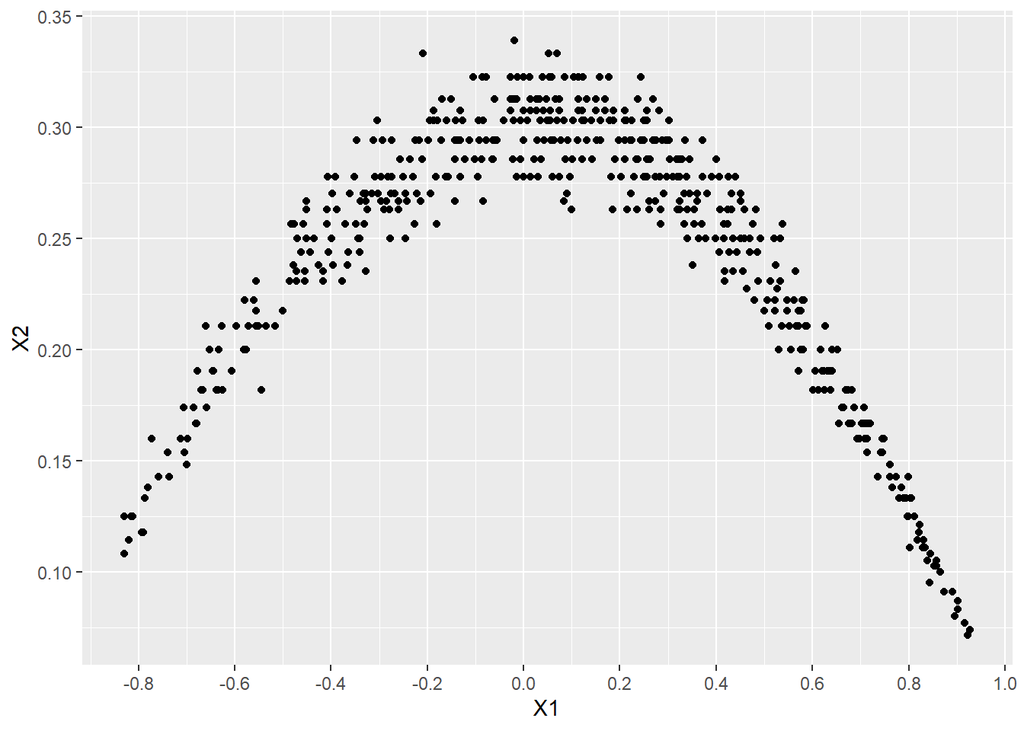

```r
homeOddsBWNoNoise =c(EPL2021NoNoise$BWH, EPL1920NoNoise$BWH, EPL1819NoNoise$BWH)
awayOddsBWNoNoise =c(EPL2021NoNoise$BWA, EPL1920NoNoise$BWA, EPL1819NoNoise$BWA)
drawOddsBWNoNoise =c(EPL2021NoNoise$BWD, EPL1920NoNoise$BWD, EPL1819NoNoise$BWD)
dfBWNoNoise = data.frame(cbind((1/homeOddsBWNoNoise)-(1/awayOddsBWNoNoise), 1/drawOddsBWNoNoise))
ggplot(dfBWNoNoise, aes(x=X1, y=X2)) + geom_point() + scale_x_continuous(breaks = c(-1,-0.8,-0.6,-0.4,-0.2,0,0.2,0.4,0.6,0.8,1))
```

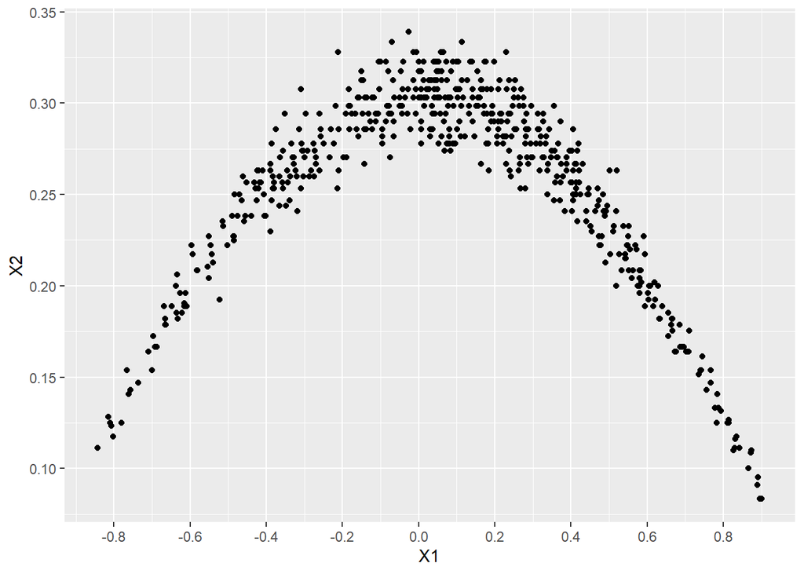

```r
homeOddsIWNoNoise =c(EPL2021NoNoise$IWH, EPL1920NoNoise$IWH, EPL1819NoNoise$IWH)
awayOddsIWNoNoise =c(EPL2021NoNoise$IWA, EPL1920NoNoise$IWA, EPL1819NoNoise$IWA)
drawOddsIWNoNoise =c(EPL2021NoNoise$IWD, EPL1920NoNoise$IWD, EPL1819NoNoise$IWD)
dfIWNoNoise = data.frame(cbind((1/homeOddsIWNoNoise)-(1/awayOddsIWNoNoise), 1/drawOddsIWNoNoise))
ggplot(dfIWNoNoise, aes(x=X1, y=X2)) + geom_point() + scale_x_continuous(breaks = c(-1,-0.8,-0.6,-0.4,-0.2,0,0.2,0.4,0.6,0.8,1))
```

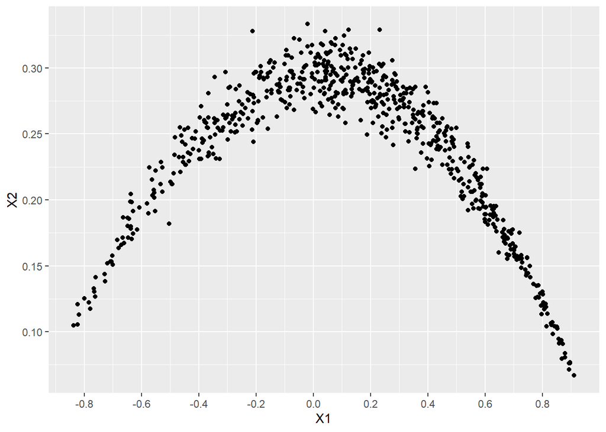

```r
homeOddsPSNoNoise =c(EPL1819NoNoise$PSH, EPL1920NoNoise$PSH, EPL2021NoNoise$PSH)
awayOddsPSNoNoise =c(EPL1819NoNoise$PSA, EPL1920NoNoise$PSA, EPL2021NoNoise$PSA)
drawOddsPSNoNoise =c(EPL1819NoNoise$PSD, EPL1920NoNoise$PSD, EPL2021NoNoise$PSD)
dfPSNoNoise = data.frame(cbind((1/homeOddsPSNoNoise)-(1/awayOddsPSNoNoise), 1/drawOddsPSNoNoise))
ggplot(dfPSNoNoise, aes(x=X1, y=X2)) + geom_point() + scale_x_continuous(breaks = c(-1,-0.8,-0.6,-0.4,-0.2,0,0.2,0.4,0.6,0.8,1))
```